# 02083673-CW2

```python
#!/usr/bin/env python3
# -*- coding: utf-8 -*-
"""
Created on Fri Dec  3 00:22:31 2021

@author: CID:02083673
"""

from scipy.spatial.distance import pdist, squareform
from scipy.signal import correlate
import sys
import os
import time
import numpy as np
import scipy.io as io
import matplotlib.pyplot as plt
from scipy.stats import pearsonr
import seaborn as sns
import networkx as nx

plt.rcParams.update({'font.size': 20})

# %% Load dataset

datadir = 'data/dataset3_m62/'
trackdata = io.loadmat(datadir+'downTrackdata.mat')
phi = trackdata['phi']
x = trackdata['x']
y = trackdata['y']
r = trackdata['r']
speed = trackdata['speed']
t = trackdata['time']
spikedata = io.loadmat(datadir+'spikes.mat')
spikes = spikedata['spikes']
params = spikedata['params']
fluodata = io.loadmat(datadir+'fissa_output.mat')
dfonf = fluodata['ddf_f']
```

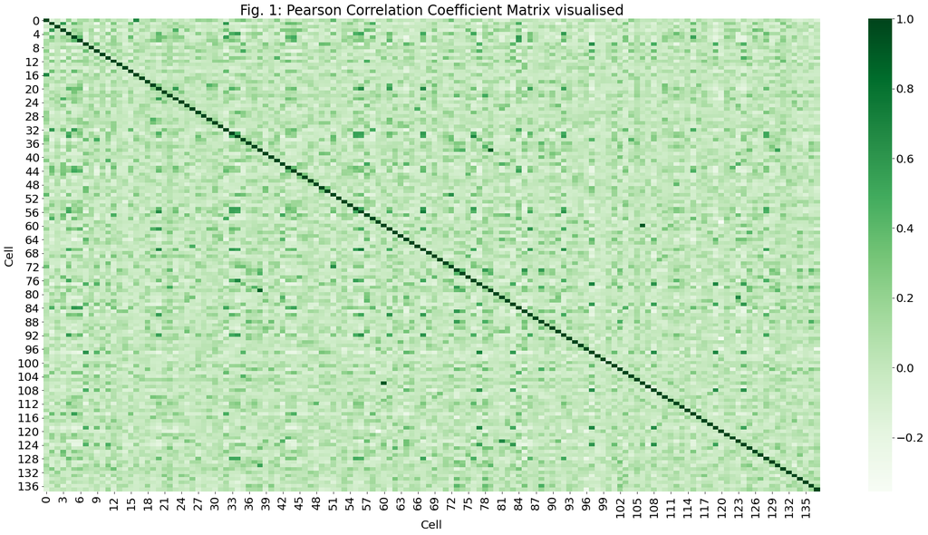

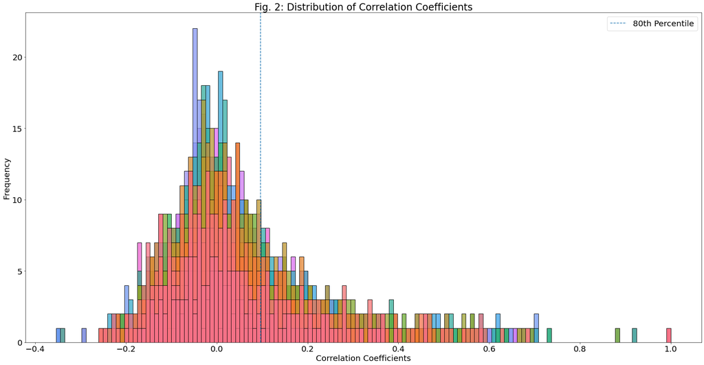

```python
# %% Task 1 - Plot, as a square image, the matrix of Pearson correlation coefficients between the calcium
# fluorescence time series from each cell. Use a colour code that ranges from -1 to 1. Label your
# axes. Now plot the distribution of correlation coefficients.
# Form an undirected graph, with nodes representing each neuron, and edges a binary variable
# which is 1 if the correlation coefficient between the time series exceeds the 80th percentile of
# the distribution of correlation coefficients between different neurons. Do not allow self-edges.
# Plot the adjacency matrix for the graph as an image. Also plot it using another graph
# visualisation method.[40 marks]


corr = np.corrcoef(dfonf)

# sns.set(font_scale=1)

plt.figure(1, [30, 15])
p1 = sns.heatmap(corr, cmap="Greens")
plt.title('Fig. 1: Pearson Correlation Coefficient Matrix visualised')
plt.xlabel('Cell')
plt.ylabel('Cell')
plt.show()

# Distribution of the matrix
plt.figure(2, [30, 15])
sns.histplot(corr, legend=False)
percentile80 = np.percentile(corr, 80) # return 80th percentile
plt.axvline(percentile80, linestyle='dashed', linewidth=1.5, label='80th Percentile')
plt.title('Fig. 2: Distribution of Correlation Coefficients')
plt.xlabel('Correlation Coefficients')
plt.ylabel('Frequency')
plt.legend()
```

Fig. 1 Demononstrates a symmetrical correlation coefficient matrix of 138 Neural Activity Time series. The graph is useful in visualising the relationship each neuron has against others and quantifies this from a scale of -1 to 1 (1 being strong positive correlation, 0 has none and -1 strong negative).

Fig. 2 illustrates the distribution of correlation coefficients against number of those found per bin. We can see that the graph is centered around 0 indicating most neural cells do not seem to be mathematically correlated at all. Another addition has been made as indicated by the legend in the top right corner; 80th Percentile. This blue dashed line represents a threshold equal to the 80th percentile and can be useful in delimiting correlation coefficients that do have a significant statistical correlation.

```
[[0 0 0 ... 0 0 0]
 [0 0 0 ... 1 0 0]
 [0 0 0 ... 0 1 0]
 ...
 [0 1 0 ... 0 0 0]
 [0 0 1 ... 0 0 1]
 [0 0 0 ... 0 1 0]]
```

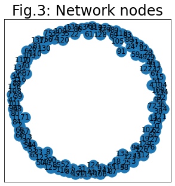

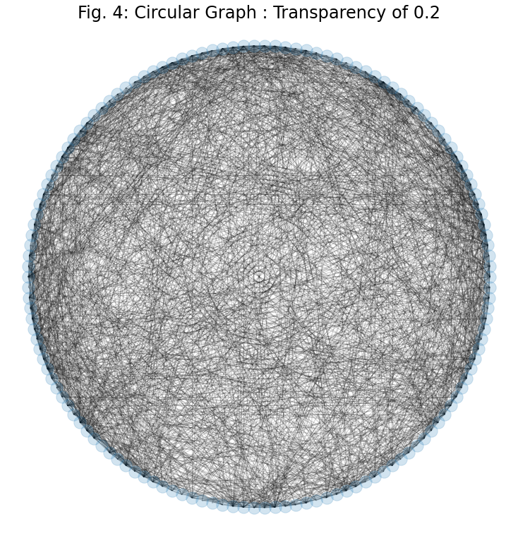

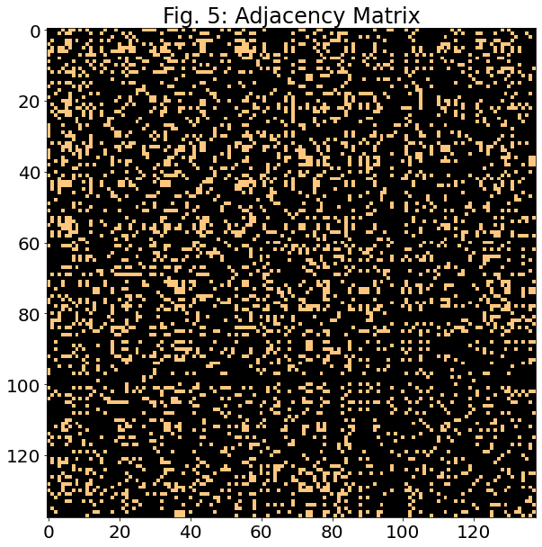

```python
#%% Forming the graph

G = nx.Graph() #empty graph

#for number in range(0, 138):
G.add_nodes_from(range(0, 138)) #Adding all neuron nodes
nodes = G.number_of_nodes() #Check if 138 neuron nodes have been made

plt.figure(3, [5, 5])
nx.draw_networkx(G)
plt.title('Fig.3: Network nodes')

# Getting edges
edgematrix = np.zeros((138,138)) #make an empty array
for y in np.arange(0,138):
    for x in np.arange(0, 138): #check array with nested loops
        if corr[x,y] > percentile80: #if the value is greater than 80th percentile
            edgematrix[x,y] = 1 #binary value 1 is edge 0 is no edge


for x in np.arange(0,138): #cheap code to ensure no self edges
    if edgematrix[x,x] == 1:
        edgematrix[x,x] = 0

# Add the edges to the graph (G)

for y in np.arange(0,138):
    for x in np.arange(0, 138): #check array with nested loops
        if edgematrix[x,y] == 1:
            G.add_edge(x, y) # add one edge for each one found

edges = G.number_of_edges() #returns how many edges have been made

plt.figure(4, [10,10])
nx.draw_circular(G, alpha=0.2)
plt.title('Fig. 4: Circular Graph : Transparency of 0.2')

#%% Get and plot the adjacency matrix

adj_mat = nx.linalg.graphmatrix.adjacency_matrix(G)

adj = adj_mat.toarray()

plt.figure(5, [10,10])
plt.imshow(adj, cmap='copper')
plt.title('Fig. 5: Adjacency Matrix')

print(adj_mat.toarray())
```

Fig. 3 is a simple circular representation of all of the nodes that the graph has (138). The edges are then incorporated as shown in Fig. 4, this is an extension of the work in the previous section where we threshold at the 80th percentile, this is now being used to create edges. An edge is the correlation between two nodes are greater than the 80th Percentile, along with this some code implementation was produced to ensure no self edges would occur (if the Correlation Coefficient is 1, and no self edge's are allowed means attributing a 0 to the edge). The figure we see in 4, represents the network entirely and by inspection seems quite messy and highly connected.

Fig. 5 Computes the adjacency matrix of the Graph we have developed for the neural data. This is a nice visualisation of the edges that occur in the previous work, as explained before Fig. 4 is very messy and hard to understand. With Fig. 5, we can clearly see where edges occur for each Cell, and where they do not! I.e. it is interesting that Cell ~120, seems to be adjacent to only approx 4 or 5 other Cells, whereas for example Cell 0, have many adjacent nodes.

```python
#%% Task 2 - What is the average degree k bar for the network described by
# the above adjacency matrix? What is the global average clustering coefficient?
# Is this high compared to what you might expect for a random network?
# What is the network diameter D? Would you describe this network as “Small
# World”?

alldegree = []
for i in np.arange(0, 138):
    alldegree.append(G.degree[i])

avDegree = sum(alldegree)/138

print('Average Degree:', avDegree)

# Average Clustering Coefficient

av_cc = nx.average_clustering(G)
print('Average Clustering Coefficient:', av_cc)


# Network D is maximum of all pairs i,j in the network of the shortest path lengths.
for y in np.arange(0,138):
   l = nx.shortest_path_length(G, y) #Network of shortest path lengths

max_value = max(l.values())  # find maximum value in list
print('Network Diameter:', max_value) # Value is 3
```

```
Average Degree: 26.594202898550726
Average Clustering Coefficient: 0.477392010026368
Network Diameter: 3
```

The implementation above runs through a few subtask but to summise: Average Degree of the Network, The Global Average Clustering Coefficient, And Network Diameter. It has been found that the quantitative data is as shown below: Average Degree: 26.594202898550726 Average Clustering Coefficient: 0.477392010026368 Network Diameter: 3

Beginning with the Average Degree, we can see it can be shown that the average amount of connections a node has is approx 27 (nearest s.f). This seems quite high, and contributes to the observation made before by inspection, the graph seems to be quite connected for the reasons if there are 138 nodes and on average all nodes are connected to 27 others, we create quite a large network of connections as shown before by Fig. 4.

The Average Clustering Coefficient: It can be shown that 0 is representative of no linkage and 1 is absolute linkage [1]. The results we found of 0.477 show that the average linkage is actually quite normal from what I understand.

Is this high for a Random Network? I would expect the average clustering to be quite random and not always make connections within local clusters and it seems like that is what this network does with an average CC value of 0.477. I believe this is not actually a random network, Neurons comply with strict biophysical/biochemical principles and this is not random, all co-ordinated by the brain and functions we have developed not because of stochasticity but purpose.

Small World: I think judging by the high Average Degree, Interesting average clustering coefficient, and the very low Network Diameter: they tell me it takes not only very few steps to get from one edge of the network to its furthest region (3), but it also tells me that each node is quite deeply located to every other node (Average 27 other nodes) which allows for a seemingly high connectivity when looked at it as an overall network. The final piece of the puzzle is the Clustering coefficients. If C is 0 then there are no links to the nodes neighbours but if it is 1, then there is a link, and we see an answer of 0.477, this tells me that there are actually just about average amounts of connections actually made overall in the system, nothing actually quite special however I feel an average clustering coefficient higher than what should be obtained by chance associated with low network diameter would provide a small world network. Ultimately, I would describe this graph as small world for the three factors I have discussed despite the seemingly average, average clustering coefficient (138x138).

```
Average Degree for ER Graph: 26.753623188405797
```

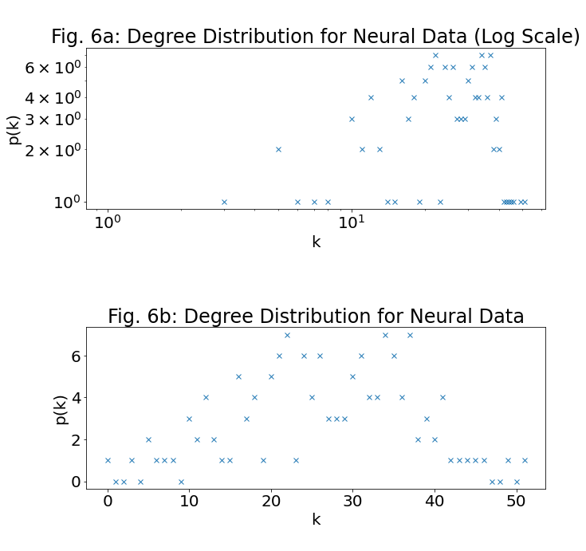

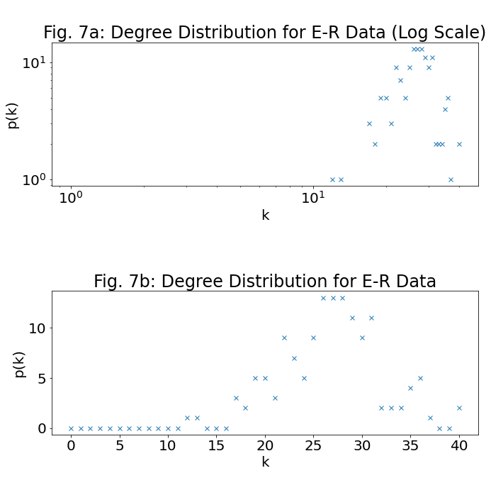

[figure not shown]

```python
#%% Task 3 - Plot the degree distribution for the network. Would you describe
# the network as “Scale-free”? Compare it to the degree distribution predicted
# by an Erdös-Renyi network of the same mean degree.

#Neural Graph
aux_y = nx.degree_histogram(G)
aux_x = np.arange(0,len(aux_y)).tolist()
n_nodes = G.number_of_nodes()

degreesNeural = [G.degree[i] for i in range(len(G.degree)) ]

#ER Graph
ER = nx.erdos_renyi_graph(138, 0.197, 100) #138 nodes, with 0.19 chance of
#creating an edge which gives the same mean degree
degreesER = [ER.degree[i] for i in range(len(ER.degree)) ]

ER_y = nx.degree_histogram(ER)
ER_x = np.arange(0,len(ER_y)).tolist()
ERn_nodes = ER.number_of_nodes()

plt.figure(6, [10,10])
plt.subplot(2,1,1)
plt.title('\nFig. 6a: Degree Distribution for Neural Data (Log Scale)')
plt.ylabel('p(k)')
plt.xlabel('k\n')
plt.xscale("log")
plt.yscale("log")
plt.plot(aux_x, aux_y, 'x')

plt.subplot(2,1,2)
plt.title('\nFig. 6b: Degree Distribution for Neural Data')
plt.ylabel('p(k)')
plt.xlabel('k\n')
plt.plot(aux_x, aux_y, 'x')
plt.tight_layout()

plt.figure(7,[10,10])
plt.subplot(2,1,1)
plt.title('\nFig. 7a: Degree Distribution for E-R Data (Log Scale)')
plt.ylabel('p(k)')
plt.xlabel('k\n')
plt.xscale("log")
plt.yscale("log")
plt.plot(ER_x, ER_y, 'x')

plt.subplot(2,1,2)
plt.title('\nFig. 7b: Degree Distribution for E-R Data')
plt.ylabel('p(k)')
plt.xlabel('k\n')
plt.plot(ER_x, ER_y, 'x')
plt.tight_layout()

ERalldegree = []
for i in np.arange(0, 138):
    ERalldegree.append(ER.degree[i])

ERavDegree = sum(ERalldegree)/138

print('Average Degree for ER Graph:', ERavDegree)
```

Fig. 6 and 7 shows seperately the Degree distributions for the Nerual data and ER respectively. Included in each figure is the logarithmic representation of the dataset and this will be explained in the next paragraph.

Would I describe the network as scale-free? No I would not. A scale free network is one with a degree distribution that follows a power law, and therefore can be given a natural scale and logarithmic but most importantly from this, they lack a scale [1]. The Random graph I believe I see, possesses a scale, where the average degree I have, provides the scale of my network. As spoken off previously, the natural log (6/7.a) has been shown of each figure in 6 and 7 along with their natural scale counterpart (6/7.b), and there is clearly no a fixed scale this network abides by and that is within one fixed power scale.

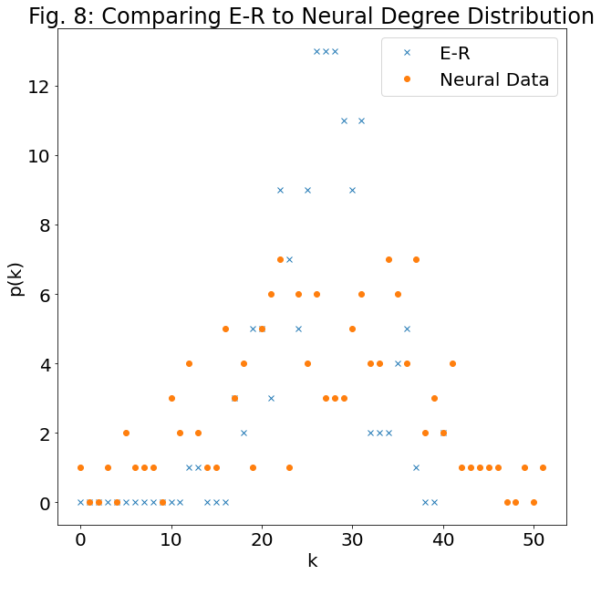

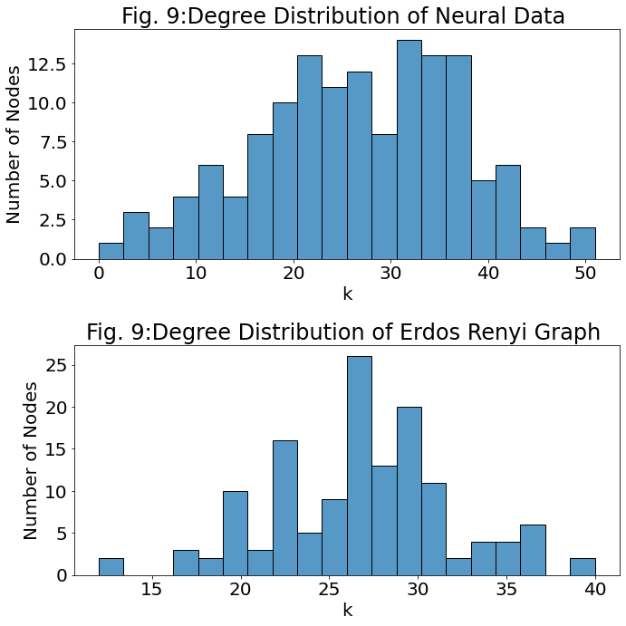

```python
plt.figure(8,[10,10])
plt.title('Fig. 8: Comparing E-R to Neural Degree Distribution')
plt.ylabel('p(k)')
plt.xlabel('k\n')
plt.plot(ER_x, ER_y, 'x', label='E-R')
plt.plot(aux_x, aux_y, 'o', label='Neural Data')
plt.legend()

plt.figure(9,[10,10])
plt.subplot(2,1,1)
sns.histplot(degreesNeural, legend=False, bins=20)
plt.title('Fig. 9:Degree Distribution of Neural Data ')
plt.xlabel('k')
plt.ylabel('Number of Nodes')

plt.subplot(2,1,2)
sns.histplot(degreesER, legend=False, bins=20)
plt.title('Fig. 9:Degree Distribution of Erdos Renyi Graph ')
plt.xlabel('k')
plt.ylabel('Number of Nodes')
plt.tight_layout()
```

[1] - Barabási, A., 2021. Network Science by Albert-László Barabási. [online] - BarabásiLab. Available at: http://networksciencebook.com/chapter/3#clustering-3-9 [Accessed 16 December 2021].